# Examen Módulo III – Análisis de Datos Multivariantes I Año 2020

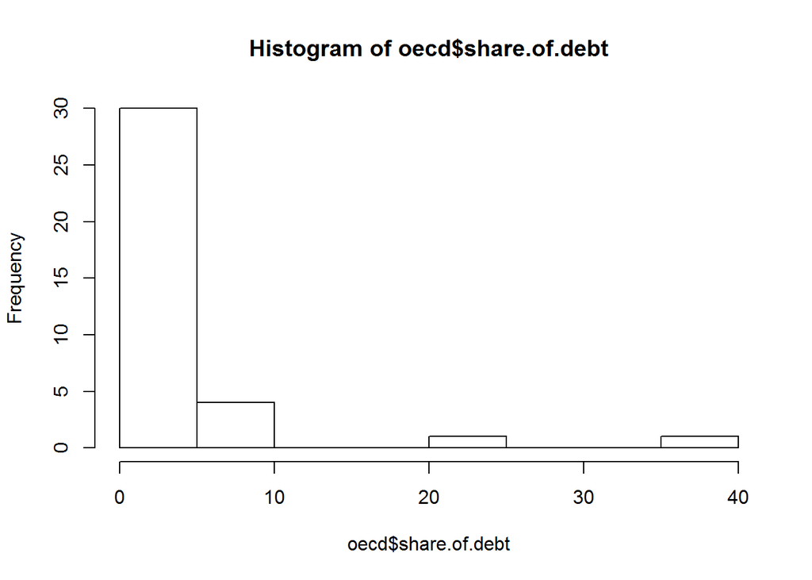

```r
hist(oecd$share.of.debt)
```

```r
g.gaus <- gam(share.of.debt ~ s(debt.gdp.ratio), family = gaussian, method = "REML", data=oecd)

g.gamma <- gam(share.of.debt ~ s(debt.gdp.ratio), family = Gamma, method = "REML", data=oecd)
# Resumen del modelo
summary(g.gaus)
```

```
##
## Family: gaussian
## Link function: identity
##
## Formula:
## share.of.debt ~ s(debt.gdp.ratio)
##
## Parametric coefficients:
##             Estimate Std. Error t value Pr(>|t|)
## (Intercept)    2.778      1.037   2.677   0.0113 *
## ---
## Signif. codes:  0 '***' 0.001 '**' 0.01 '*' 0.05 '.' 0.1 ' ' 1
##
## Approximate significance of smooth terms:
##                   edf Ref.df     F p-value
## s(debt.gdp.ratio)   1      1 9.465 0.00405 **
## ---
## Signif. codes:  0 '***' 0.001 '**' 0.01 '*' 0.05 '.' 0.1 ' ' 1
##
## R-sq.(adj) =  0.195   Deviance explained = 21.8%
## -REML =    114  Scale est. = 38.749    n = 36
```

```r
# Resumen del modelo
summary(g.gamma)
```

```
##
## Family: Gamma
## Link function: inverse
##
## Formula:
## share.of.debt ~ s(debt.gdp.ratio)
##
## Parametric coefficients:
##             Estimate Std. Error t value Pr(>|t|)
## (Intercept)   1.3946     0.3299   4.228 0.000197 ***
## ---
## Signif. codes:  0 '***' 0.001 '**' 0.01 '*' 0.05 '.' 0.1 ' ' 1
##
## Approximate significance of smooth terms:
##                     edf Ref.df    F p-value
## s(debt.gdp.ratio) 4.365  5.253 3.43  0.0129 *
## ---
## Signif. codes:  0 '***' 0.001 '**' 0.01 '*' 0.05 '.' 0.1 ' ' 1
##
## R-sq.(adj) =   0.39   Deviance explained = 55.7%
## -REML = 50.336  Scale est. = 1.5797    n = 36
```

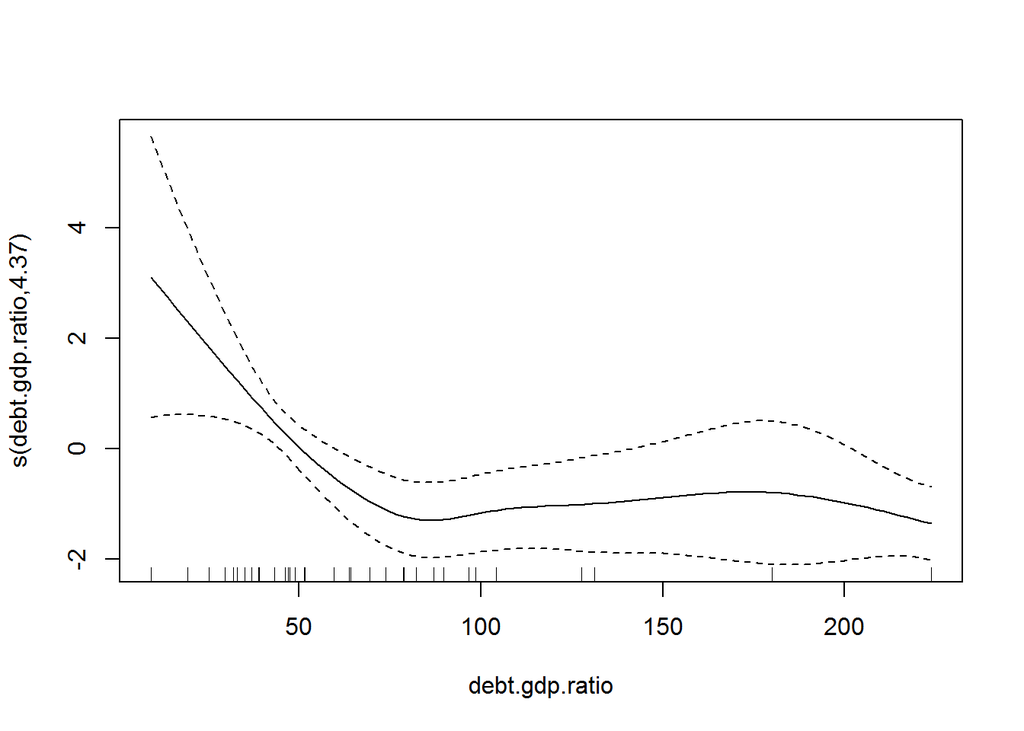

```r
plot.gam(g.gamma)
```

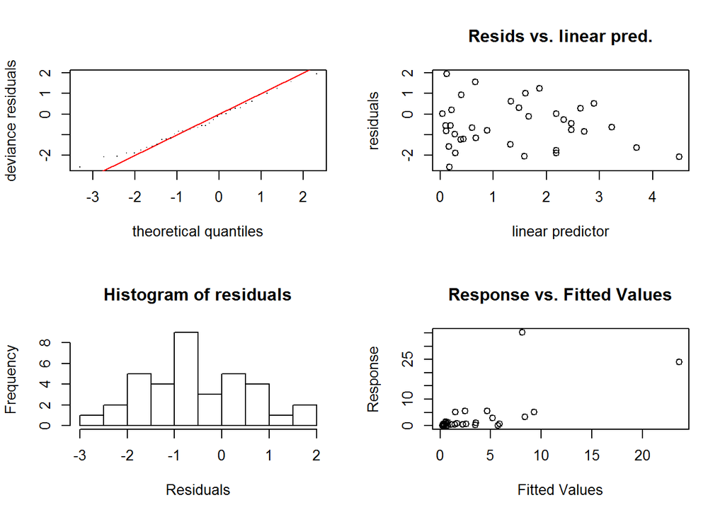

```
##
## Method: REML   Optimizer: outer newton
## full convergence after 7 iterations.
## Gradient range [-7.430479e-08,2.571407e-08]
## (score 50.3358 & scale 1.579689).
## Hessian positive definite, eigenvalue range [0.9411205,23.68462].
## Model rank =  10 / 10
##
## Basis dimension (k) checking results. Low p-value (k-index<1) may
## indicate that k is too low, especially if edf is close to k'.
##
##                     k'  edf k-index p-value
## s(debt.gdp.ratio) 9.00 4.37     0.8    0.45
```

```r
gam.check(g.gamma)
```

## Ejercicio 6

Los datos contenidos en el fichero avena.csv corresponden a las cosechas de tres variedades de avena (expresadas como 1/4 lb por sub-plot, cada uno de 1/80 acre). Hay seis bloques (I-VI) y cuatro tratamientos de fertilización con nitrógeno. [Fuente: Venables y Ripley (2002), pág. 282.] Establezca el diseño asociado a este experimento y estime los distintos efectos a través del correspondiente modelo lineal.

```r
setwd("C:")
getwd()
```

```
## [1] "C:/Users/rsm_000/Desktop"
```

```r
avena <-read.csv("avena.csv", sep = ";", header = TRUE)
str(avena)
```

```
## 'data.frame':    72 obs. of  4 variables:
##  $ block  : Factor w/ 6 levels "I","II","III",..: 1 1 1 1 1 1 1 1 1 1 ...
##  $ variety: Factor w/ 3 levels "Golden Rain",..: 3 3 3 3 1 1 1 1 2 2 ...
##  $ nitro  : Factor w/ 4 levels "0","0,2","0,4",..: 1 2 3 4 1 2 3 4 1 2 ...
##  $ yield  : int  111 130 157 174 117 114 161 141 105 140 ...
```

```r
head(avena)
```

```
##   block     variety nitro yield
## 1     I     Victory     0   111
## 2     I     Victory   0,2   130
## 3     I     Victory   0,4   157
## 4     I     Victory   0,6   174
## 5     I Golden Rain     0   117
## 6     I Golden Rain   0,2   114
```

Por tanto, las parcelas están anidadas en el efecto variedad y el tratamiento cruzado con el efecto bloque. El modelo a ajustar sería: WholePlot+Subplot

El análisis de la varianza lo obtenemos:

```r
avena_df<-avena
avena_df$N <- factor(avena$nitro)
avena_df$N <- ordered(avena_df$N, levels = sort(levels(avena_df$N)))
avena_df <- cbind.data.frame(B = avena$block, V = avena$variety, N = avena_df$N, Y = avena$yield)
avena.aov <- aov(Y ~ B+N*V + Error(B/V), qr=T, data = avena_df) #response ~ mean.formula + Error(strata.formula)
# Resumen del modelo
summary(avena.aov)
```

```
##
## Error: B
##   Df Sum Sq Mean Sq
## B  5  15875    3175
##
## Error: B:V
##           Df Sum Sq Mean Sq F value Pr(>F)
## V          2   1786   893.2   1.485  0.272
## Residuals 10   6013   601.3
##
## Error: Within
##           Df Sum Sq Mean Sq F value   Pr(>F)
## N          3  20020    6673  37.686 2.46e-12 ***
## N:V        6    322      54   0.303    0.932
## Residuals 45   7969     177
## ---
## Signif. codes:  0 '***' 0.001 '**' 0.01 '*' 0.05 '.' 0.1 ' ' 1
```

Hay un claro efecto de nitrógeno. La configuración del modelo usando lmer(), se haría del siguiente modo.

```r
library(lme4)
```

```r
modelo_split_plot <-lmer(Y ~ B + N * V  + (1 | B:V), data = avena_df)
# Resumen del modelo
summary(modelo_split_plot)
```

```
## Linear mixed model fit by REML ['lmerMod']
## Formula: Y ~ B + N * V + (1 | B:V)
##    Data: avena_df
##
## REML criterion at convergence: 489.3
##
## Scaled residuals:
##      Min       1Q   Median       3Q      Max
## -1.78868 -0.55501 -0.07274  0.61288  1.60271
##
## Random effects:
##  Groups   Name        Variance Std.Dev.
##  B:V      (Intercept) 106.1    10.30
##  Residual             177.1    13.31
## Number of obs: 72, groups:  B:V, 18
##
## Fixed effects:
##                 Estimate Std. Error t value
## (Intercept)     135.8611     8.1740  16.621
## BII             -28.0833    10.0111  -2.805
## BIII            -39.4167    10.0111  -3.937
## BIV             -37.1667    10.0111  -3.713
## BV              -44.4167    10.0111  -4.437
## BVI             -39.0833    10.0111  -3.904
## N.L              33.6901     5.4327   6.201
## N.Q              -4.1667     5.4327  -0.767
## N.C              -0.8199     5.4327  -0.151
## VMarvellous       5.2917     7.0789   0.748
## VVictory         -6.8750     7.0789  -0.971
## N.L:VMarvellous  -4.8075     7.6830  -0.626
## N.Q:VMarvellous  -1.9167     7.6830  -0.249
## N.C:VMarvellous   3.9877     7.6830   0.519
## N.L:VVictory      2.5715     7.6830   0.335
## N.Q:VVictory     -1.0833     7.6830  -0.141
## N.C:VVictory     -2.8696     7.6830  -0.374
```

```
##
## Correlation matrix not shown by default, as p = 17 > 12.
## Use print(x, correlation=TRUE)  or
##     vcov(x)        if you need it
```

## Ejercicio 7

El data frame UCBAdmissions del paquete datasets contiene datos agregados sobre los solicitantes a la escuela de posgrado en Berkeley para los seis departamentos más grandes en 1973 clasificados por admisión y sexo. El objetivo del estudio es determinar si existe discriminación contra las mujeres en este tipo de ámbitos, y, por tanto, interesa conocer el efecto de la variable Gender en la probabilidad de resultar admitido. Estime, para ello, un modelo de regresión logística. Nota: especificar la frecuencia a través del parámetro weights.

```r
library(datasets)
USBA <- data.frame(UCBAdmissions)
str(USBA)
```

```
## 'data.frame':    24 obs. of  4 variables:
##  $ Admit : Factor w/ 2 levels "Admitted","Rejected": 1 2 1 2 1 2 1 2 1 2 ...
##  $ Gender: Factor w/ 2 levels "Male","Female": 1 1 2 2 1 1 2 2 1 1 ...
##  $ Dept  : Factor w/ 6 levels "A","B","C","D",..: 1 1 1 1 2 2 2 2 3 3 ...
##  $ Freq  : num  512 313 89 19 353 207 17 8 120 205 ...
```

```r
head(USBA)
```

```
##      Admit Gender Dept Freq
## 1 Admitted   Male    A  512
## 2 Rejected   Male    A  313
## 3 Admitted Female    A   89
## 4 Rejected Female    A   19
## 5 Admitted   Male    B  353
## 6 Rejected   Male    B  207
```

Por defecto, Admitir está codificado de modo que Admitido sea el nivel 1 y Rechazado sea el nivel 2 (debido a su orden alfabético). Como glm () asumirá que el nivel 2 representa “éxito”, revertiremos la codificación de Admitir, por lo que pronosticamos la probabilidad de admisión en lugar de rechazo. Para cambiar la codificación de una variable, puede usar la función fct_relevel () del paquete forcats.

```r
library(forcats)
# Invierta la codificación de la variable Admit
USBA$Admit <- fct_relevel(USBA$Admit, "Rejected", "Admitted")
# Regresion logistica
glm_gender <- glm(Admit ~ Gender, data = USBA, weight = Freq, family = "binomial")
# Resumen del modelo
summary(glm_gender)
```

```
##
## Call:
## glm(formula = Admit ~ Gender, family = "binomial", data = USBA,
##     weights = Freq)
##
## Deviance Residuals:
##     Min       1Q   Median       3Q      Max
## -20.336  -15.244    1.781   14.662   28.787
##
## Coefficients:
##              Estimate Std. Error z value Pr(>|z|)
## (Intercept)  -0.22013    0.03879  -5.675 1.38e-08 ***
## GenderFemale -0.61035    0.06389  -9.553  < 2e-16 ***
## ---
## Signif. codes:  0 '***' 0.001 '**' 0.01 '*' 0.05 '.' 0.1 ' ' 1
##
## (Dispersion parameter for binomial family taken to be 1)
##
##     Null deviance: 6044.3  on 23  degrees of freedom
## Residual deviance: 5950.9  on 22  degrees of freedom
## AIC: 5954.9
##
## Number of Fisher Scoring iterations: 4
```

```r
exp(-0.61035)
```

```
## [1] 0.5431607
```

Efectivamente, cuando predice la probabilidad de admisión en función del género solo, el efecto es estadísticamente significativo (p <0.01).El efecto de la variable Gender en la probabilidad de resultar admitido es exp (0.61035) = 0.54.

```r
glm_genderdebt <- glm(Admit ~ Gender + Dept, weights = Freq, data=USBA,family=binomial)
summary(glm_genderdebt)
```

```
##
## Call:
## glm(formula = Admit ~ Gender + Dept, family = binomial, data = USBA,
##     weights = Freq)
##
## Deviance Residuals:
##      Min        1Q    Median        3Q       Max
## -25.3424  -13.0584   -0.1631   16.0167   21.3199
##
## Coefficients:
##              Estimate Std. Error z value Pr(>|z|)
## (Intercept)   0.58205    0.06899   8.436   <2e-16 ***
## GenderFemale  0.09987    0.08085   1.235    0.217
## DeptB        -0.04340    0.10984  -0.395    0.693
## DeptC        -1.26260    0.10663 -11.841   <2e-16 ***
## DeptD        -1.29461    0.10582 -12.234   <2e-16 ***
## DeptE        -1.73931    0.12611 -13.792   <2e-16 ***
## DeptF        -3.30648    0.16998 -19.452   <2e-16 ***
## ---
## Signif. codes:  0 '***' 0.001 '**' 0.01 '*' 0.05 '.' 0.1 ' ' 1
##
## (Dispersion parameter for binomial family taken to be 1)
##
##     Null deviance: 6044.3  on 23  degrees of freedom
## Residual deviance: 5187.5  on 17  degrees of freedom
## AIC: 5201.5
##
## Number of Fisher Scoring iterations: 6
```